# IgE levels in multi test patients

Author

Alexander W. Gofton & Emily Smith

Published

March 13, 2026

## Setup

Load CSIRO colour palette and required packages for data manipulation and plot composition.

```r
source("code/CSIRO_colours.R")
library(tidyverse)
library(patchwork)
```

## Plot Theme

Configure the global ggplot theme for IgE level visualisations.

```r
# Figure theme
theme_set(
  theme_classic() +
    theme(
      panel.grid.major.y = element_line(colour = "grey60", linewidth = 0.1),
      panel.grid.minor = element_blank(),
      axis.text.x = element_text(size = 11),
      axis.text.y = element_text(size = 11),
      axis.title.y = element_text(size = 12),
      axis.title.x = element_text(size = 12),
      axis.line = element_line(colour = "grey60"),
      axis.ticks = element_line(colour = "grey60"),
      text = element_text(family = "Arial")
    )
)
```

# Load Data

Import the multiple-test patient dataset, order tests chronologically within each patient, and assign sequential test numbers.

```r
multi_test_df <- read.csv("data/preprocessed_with_SA_info_only_multi.csv") |>
  mutate(pat_ID = as.character(pat_ID)) |>
  group_by(pat_ID) |>
  arrange(YOT, .by_group = TRUE) |> # Order tests by date within each patient
  mutate(
    test_cat = row_number(), # Create sequential test category
  ) |>
  ungroup() |>
  mutate(Age = YOT - YOB)
```

# Exploratory Data Analysis

Summarise the characteristics of patients with multiple alpha-gal tests, including the number of repeat tests, inter-test intervals, and seroconversion patterns.

```r
# How many people recieved multiple tests?
tests_per_patient <- multi_test_df |>
  group_by(pat_ID) |>
  summarise(n_tests = n()) |>
  ungroup()

# Total number of patients with multiple tests
total_multi_test_patients <- n_distinct(multi_test_df$pat_ID)
cat(sprintf(
  "Total patients with multiple tests: %d\n",
  total_multi_test_patients
))

# Breakdown by number of tests
tests_per_patient |>
  count(n_tests) |>
  arrange(desc(n_tests))
```

```
Total patients with multiple tests: 1516
# A tibble: 13 × 2
   n_tests     n
     <int> <int>
 1      17     1
 2      15     1
 3      13     1
 4      11     2
 5      10     4
 6       9     5
 7       8     7
 8       7    17
 9       6    17
10       5    50
11       4   122
12       3   259
13       2  1030
```

## Distribution of Test Counts

Visualise the frequency distribution of the number of tests per patient.

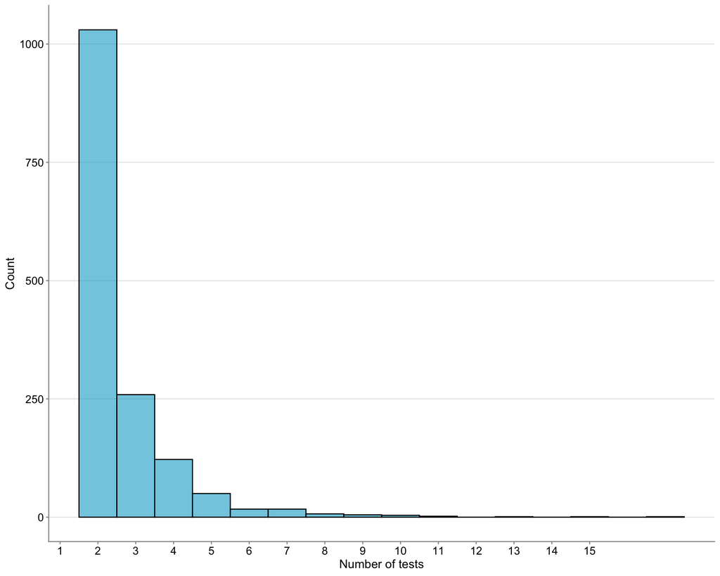

```r
# Histogram
histogram <- multi_test_df |>
  count(pat_ID) |>
  ggplot(aes(x = n)) +
  geom_histogram(
    binwidth = 1,
    color = "black",
    fill = MiddayBlue,
    alpha = 0.6
  ) +
  scale_x_continuous(breaks = seq(1, 15, 1)) +
  labs(
    y = "Count",
    x = "Number of tests"
  )

histogram
```

## Patients with at Least One Positive Result

```r
# How many were positive at least once?
multi_test_df |>
  filter(Status == "Positive") |>
  summarise(n_distinct(pat_ID))
```

```
# A tibble: 1 × 1
  `n_distinct(pat_ID)`
                 <int>
1                 1161
```

```r
# How many people?
multi_test_df |>
  #filter(Status == "Positive") |>
  summarise(n_distinct(pat_ID))
```

```
# A tibble: 1 × 1
  `n_distinct(pat_ID)`
                 <int>
1                 1516
```

```r
tests_per_patient <- multi_test_df |>
  group_by(pat_ID) |>
  summarise(n_tests = n()) |>  # <-- Column is called n_tests
  ungroup()

tests_per_patient
```

```
# A tibble: 1,516 × 2
   pat_ID    n_tests
   <chr>       <int>
 1 100001543       3
 2 100030438       7
 3 100034150       2
 4 100045177       2
 5 100092393       2
 6 100099172       3
 7 100265554       3
 8 100314438       2
 9 100372118       2
10 100380748       2
# ℹ 1,506 more rows
```

## Summary Statistics for Tests per Patient

Calculate the median, mean, minimum, and maximum number of tests received per patient.

```r
# Median number of tests per person
median(tests_per_patient$n_tests)

# Or more detailed breakdown
tests_per_patient %>%
  summarise(
    median_tests = median(n_tests),
    mean_tests = mean(n_tests),
    min_tests = min(n_tests),
    max_tests = max(n_tests),
    total_patients = n()
  )
```

```
[1] 2
# A tibble: 1 × 5
  median_tests mean_tests min_tests max_tests total_patients
         <dbl>      <dbl>     <int>     <int>          <int>
1            2       2.64         2        17           1516
```

## Inter-Test Intervals

Calculate the number of years between consecutive tests for each patient.

```r
# Calculate the number of years between tests for each patient
years_between_tests <- multi_test_df |>
  group_by(pat_ID) |>
  arrange(YOT, .by_group = T) |>
  mutate(years_between_test = as.numeric(YOT - lag(YOT))) |>
  ungroup() |>
  filter(!is.na(years_between_test))

glimpse(years_between_tests)
```

```
Rows: 2,488
Columns: 20
$ postcode           <int> 2483, 2483, 2454, 2454, 2454, 2454, 2454, 2454, 481…
$ SA3_code           <int> 11201, 11201, 10402, 10402, 10402, 10402, 10402, 10…
$ SA3_name           <chr> "Richmond Valley - Coastal", "Richmond Valley - Coa…
$ Episode_num        <chr> "637945899", "651179897", "661759277", "667246008",…
$ pat_ID             <chr> "100001543", "100001543", "100030438", "100030438",…
$ Sex                <chr> "M", "M", "F", "F", "F", "F", "F", "F", "M", "M", "…
$ DOT                <chr> "2017-07-20", "2020-02-04", "2021-08-02", "2022-05-…
$ aGal               <dbl> 6.02, 4.18, 0.31, 0.10, 0.05, 0.07, 0.44, 0.27, 14.…
$ ref_pc             <int> 2482, 2481, 2454, 2454, 2454, 2454, 2454, 2454, 488…
$ Provider           <chr> "SNP", "SNP", "SNP", "SNP", "SNP", "SNP", "SNP", "S…
$ YOB                <int> 1970, 1970, 1963, 1963, 1963, 1963, 1963, 1963, 195…
$ YOT                <int> 2017, 2020, 2021, 2022, 2022, 2023, 2024, 2024, 202…
$ date_col           <chr> NA, NA, NA, NA, NA, NA, NA, NA, NA, NA, NA, NA, NA,…
$ Age                <int> 47, 50, 58, 59, 59, 60, 61, 61, 68, 61, 45, 54, 58,…
$ Under_LD           <lgl> FALSE, FALSE, FALSE, FALSE, FALSE, FALSE, FALSE, FA…
$ Status             <chr> "Positive", "Positive", "Positive", "Positive", "Ne…
$ SA4_code           <int> 112, 112, 104, 104, 104, 104, 104, 104, 318, 316, 3…
$ SA4_name           <chr> "Richmond - Tweed", "Richmond - Tweed", "Coffs Harb…
$ test_cat           <int> 2, 3, 2, 3, 4, 5, 6, 7, 2, 2, 2, 2, 3, 2, 3, 2, 2, …
$ years_between_test <dbl> 3, 3, 1, 1, 0, 1, 1, 0, 1, 3, 7, 5, 4, 0, 1, 0, 3, …
```

### Overall Gap Summary

Summarise the distribution of inter-test intervals across all patient-test pairs.

```r
# Summary statistics for years between tests
overall_gap_summary <- years_between_tests |>
  summarise(
    n_intervals = n(),
    mean_gap = mean(years_between_test, na.rm = TRUE),
    median_gap = median(years_between_test, na.rm = TRUE),
    sd_gap = sd(years_between_test, na.rm = TRUE),
    IQR_gap = IQR(years_between_test, na.rm = TRUE),
    min_gap = min(years_between_test, na.rm = TRUE),
    max_gap = max(years_between_test, na.rm = TRUE)
  )

overall_gap_summary
```

```
# A tibble: 1 × 7
  n_intervals mean_gap median_gap sd_gap IQR_gap min_gap max_gap
        <int>    <dbl>      <dbl>  <dbl>   <dbl>   <dbl>   <dbl>
1        2488     1.49          1   1.60    1.25       0      10
```

### Distribution of Inter-Test Intervals

Histogram of the number of years between consecutive tests.

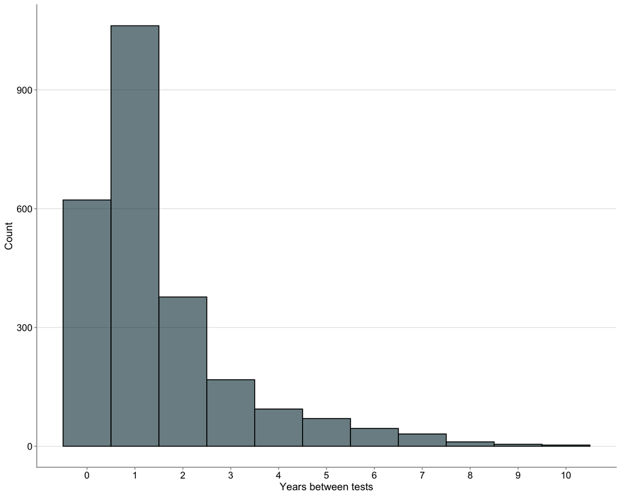

```r
#  Plot the distribution of years between tests
ggplot(years_between_tests, aes(x = years_between_test)) +
  geom_histogram(
    binwidth = 1,
    fill = MidnightBlue,
    color = "black",
    alpha = 0.6
  ) +
  scale_x_continuous(breaks = seq(0, 10, 1)) +
  labs(
    x = "Years between tests",
    y = "Count"
  )
```

### Per-Patient Average Gap

Calculate the average inter-test interval for each individual patient.

```r
# Calculate the average gap in years between tests for each patient
per_patient_gap <- years_between_tests |>
  group_by(pat_ID) |>
  summarise(
    n_intervals = n(),
    avg_gap = mean(years_between_test, na.rm = TRUE),
    med_gap = median(years_between_test, na.rm = TRUE)
  )

head(per_patient_gap)
```

```
# A tibble: 6 × 4
  pat_ID    n_intervals avg_gap med_gap
  <chr>           <int>   <dbl>   <dbl>
1 100001543           2   3         3
2 100030438           6   0.667     1
3 100034150           1   1         1
4 100045177           1   3         3
5 100092393           1   7         7
6 100099172           2   4.5       4.5
```

### Summary of Patient-Level Average Gaps

```r
# And overall summary of those averages:
per_patient_gap |>
  summarise(
    mean_of_avg = mean(avg_gap),
    median_of_med = median(med_gap),
    sd_of_avg = sd(avg_gap),
    min_avg_gap = min(avg_gap),
    max_avg_gap = max(avg_gap)
  )
```

```
# A tibble: 1 × 5
  mean_of_avg median_of_med sd_of_avg min_avg_gap max_avg_gap
        <dbl>         <dbl>     <dbl>       <dbl>       <dbl>
1        1.70             1      1.74           0          10
```

## Seroconversion Detection

Identify patients whose first test was negative but who subsequently tested positive, indicating potential seroconversion.

```r
# Identify patient IDs where test_cat 1 is Negative and any subsequent test is Positive
flagged_patients <- multi_test_df |>
  group_by(pat_ID) |>
  arrange(test_cat, .by_group = TRUE) |>
  summarise(
    first_status = first(Status),
    any_positive_after = any(test_cat > 1 & Status == "Positive")
  ) |>
  filter(first_status == "Negative", any_positive_after) |>
  pull(pat_ID)


# Filter the full data frame for those patients
flagged_patients_df <- multi_test_df |>
  filter(pat_ID %in% flagged_patients) |>
  dplyr::select(pat_ID, test_cat, aGal, YOT, Status, YOB, Sex)
```

# Alpha-gal sIgE Level Changes Between Tests

Examine how alpha-gal specific IgE concentrations change across sequential tests in patients with positive results, using log-transformed values and GLM trend fitting.

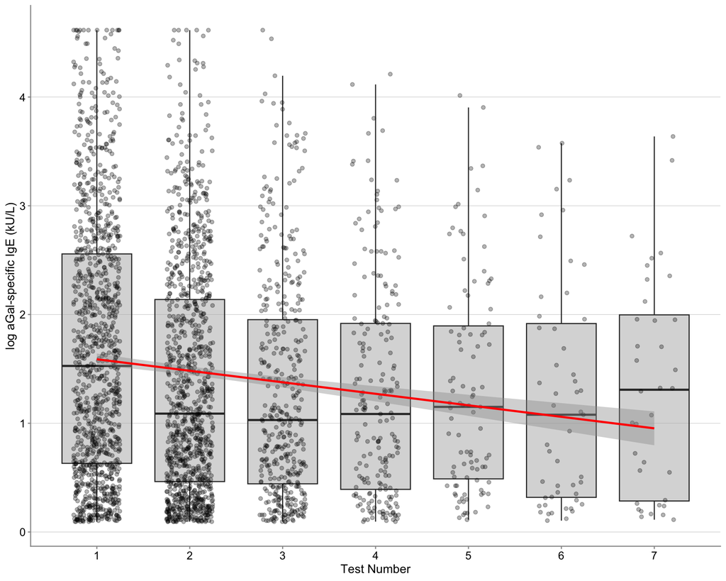

```r
multi_test_df |>
  filter(Status == "Positive") |>
  group_by(pat_ID) |>
  mutate(
    log_aGal = log(aGal + 1),
    test_cat_num = as.numeric(test_cat)
  ) |>
  ungroup() |>
  filter(test_cat <= 7) |>
  ggplot(aes(x = test_cat_num, y = log_aGal)) +
  geom_boxplot(
    aes(group = test_cat_num),
    fill = "grey70",
    alpha = 0.5,
    outlier.shape = NA
  ) +
  geom_jitter(width = 0.25, alpha = 0.3) +
  geom_smooth(
    method = "glm",
    se = TRUE,
    color = "red",
    lty = 1,
    lwd = 1
  ) +
  labs(
    x = "Test Number",
    y = "log aGal-specific IgE (kU/L)"
  ) +
  scale_x_continuous(breaks = 1:7)
```

# Proportion of Patients with Declining sIgE Levels

Quantify the proportion of patients whose alpha-gal sIgE levels decreased between consecutive tests and summarise the time course of decline.

```r
# Calculate change in aGal levels between consecutive tests for each patient
aGal_changes <- multi_test_df |>
  group_by(pat_ID) |>
  arrange(YOT, .by_group = TRUE) |>
  mutate(
    test_cat = row_number(),
    log_aGal = log(aGal + 1),
    prev_aGal = lag(aGal),
    prev_log_aGal = lag(log_aGal),
    aGal_change = aGal - prev_aGal,
    log_aGal_change = log_aGal - prev_log_aGal,
    time_between = as.numeric(YOT - lag(YOT)),
    decreased = aGal_change < 0
  ) |>
  filter(!is.na(prev_aGal)) |> # Remove first test for each patient
  ungroup()

# Calculate proportion of patients who had at least one decrease
patients_with_decrease <- aGal_changes |>
  group_by(pat_ID) |>
  summarise(
    had_decrease = any(decreased, na.rm = TRUE),
    n_tests = n() + 1, # Add 1 because we filtered out first test
    n_decreases = sum(decreased, na.rm = TRUE),
    prop_decreases = n_decreases / n(),
    total_change = last(log_aGal) - first(prev_log_aGal),
    total_time = sum(time_between, na.rm = TRUE)
  ) |>
  ungroup()

# Overall summary
decrease_summary <- patients_with_decrease |>
  summarise(
    n_patients = n(),
    n_with_decrease = sum(had_decrease),
    prop_with_decrease = mean(had_decrease),
    mean_time_to_decrease = mean(total_time[had_decrease], na.rm = TRUE),
    median_time_to_decrease = median(total_time[had_decrease], na.rm = TRUE)
  )

print("Summary of aGal level changes:")
print(decrease_summary)
```

```
[1] "Summary of aGal level changes:"
# A tibble: 1 × 5
  n_patients n_with_decrease prop_with_decrease mean_time_to_decrease
       <int>           <int>              <dbl>                 <dbl>
1       1516            1032              0.681                  2.82
# ℹ 1 more variable: median_time_to_decrease <dbl>
```

# Statistical Modelling of sIgE Trajectories

Apply linear mixed-effects models to test whether alpha-gal sIgE levels decrease systematically across sequential tests, accounting for individual patient variation.

```r
library(lme4) # For mixed-effects models
library(broom) # For tidy model output
library(broom.mixed) # For mixed-effects model output
library(survival) # For time-to-event analysis
library(coin) # For non-parametric tests
```

## Overall Cohort Analysis

### Linear Mixed-Effects Model: sIgE vs Test Number

This tests whether there’s a significant linear decrease in aGal levels across sequential tests, accounting for individual patient variation.

```r
# Prepare data for mixed-effects modeling
positive_patients_lme <- multi_test_df %>%
  # Remove patients who never had a positive test
  group_by(pat_ID) %>%
  filter(any(Status == "Positive")) %>%
  ungroup() %>%
  mutate(
    log_aGal = log(aGal + 1),
    test_cat_centered = test_cat - 1 # Start from 0 for interpretation
  ) #%>%
  #filter(test_cat <= 7) # Focus on first 7 tests for stability

# Fit linear mixed-effects model
lme_model <- lmer(
  log_aGal ~ test_cat_centered + (1 + test_cat_centered | pat_ID),
  data = positive_patients_lme,
  control = lmerControl(optimizer = "bobyqa")
)

# Model summary
summary(lme_model)

# Extract key statistics
lme_results <- tidy(lme_model, effects = "fixed")

# Calculate p-values using Wald test (normal approximation)
lme_results <- lme_results %>%
  mutate(
    t_value = estimate / std.error,
    p.value = 2 * (1 - pnorm(abs(t_value))),
    significant = p.value < 0.05,
    effect_size = case_when(
      term == "test_cat_centered" ~
        paste0(round(estimate, 4), " log units per test"),
      TRUE ~ as.character(round(estimate, 4))
    )
  )

print("Linear Mixed-Effects Model Results:")
print(lme_results)

# Calculate confidence intervals
lme_ci <- confint(lme_model, method = "Wald")
print("95% Confidence Intervals:")
print(lme_ci)
```

```
Linear mixed model fit by REML ['lmerMod']
Formula: log_aGal ~ test_cat_centered + (1 + test_cat_centered | pat_ID)
   Data: positive_patients_lme
Control: lmerControl(optimizer = "bobyqa")

REML criterion at convergence: 8719.3

Scaled residuals:
    Min      1Q  Median      3Q     Max
-3.2889 -0.4487 -0.1160  0.4163  3.6589

Random effects:
 Groups   Name              Variance Std.Dev. Corr
 pat_ID   (Intercept)       0.98221  0.9911
          test_cat_centered 0.05795  0.2407   -0.48
 Residual                   0.39456  0.6281
Number of obs: 3258, groups:  pat_ID, 1161

Fixed effects:
                  Estimate Std. Error t value
(Intercept)        1.53127    0.03317   46.17
test_cat_centered -0.20843    0.01539  -13.54

Correlation of Fixed Effects:
            (Intr)
tst_ct_cntr -0.474
[1] "Linear Mixed-Effects Model Results:"
# A tibble: 2 × 9
  effect term           estimate std.error statistic t_value p.value significant
  <chr>  <chr>             <dbl>     <dbl>     <dbl>   <dbl>   <dbl> <lgl>
1 fixed  (Intercept)       1.53     0.0332      46.2    46.2       0 TRUE
2 fixed  test_cat_cent…   -0.208    0.0154     -13.5   -13.5       0 TRUE
# ℹ 1 more variable: effect_size <chr>
[1] "95% Confidence Intervals:"
                       2.5 %     97.5 %
.sig01                    NA         NA
.sig02                    NA         NA
.sig03                    NA         NA
.sigma                    NA         NA
(Intercept)        1.4662678  1.5962727
test_cat_centered -0.2385938 -0.1782719
```

## Individual Patient Variation Analysis

Extract individual patient slopes

```r
# Extract random effects (individual patient deviations) and make safe names
library(tibble)

ranef_df <- ranef(lme_model)$pat_ID %>%
  as.data.frame() %>%
  tibble::rownames_to_column("pat_ID") %>%
  rename(
    random_intercept = `(Intercept)`,
    random_slope = test_cat_centered
  )

# Fixed-effect estimates (safe lookup by term)
fixed_intercept <- lme_results$estimate[lme_results$term == "(Intercept)"]
fixed_slope <- lme_results$estimate[lme_results$term == "test_cat_centered"]

# Calculate individual slopes (fixed + random) and intercepts
individual_slopes <- ranef_df %>%
  mutate(
    individual_slope = fixed_slope + random_slope,
    individual_intercept = fixed_intercept + random_intercept,
    decreasing = individual_slope < 0
  ) %>%
  arrange(individual_slope)

# Summary of individual slopes
slope_summary <- individual_slopes %>%
  summarise(
    n_patients = n(),
    n_decreasing = sum(decreasing),
    prop_decreasing = mean(decreasing),
    mean_slope = mean(individual_slope),
    median_slope = median(individual_slope),
    min_slope = min(individual_slope),
    max_slope = max(individual_slope),
    sd_slope = sd(individual_slope)
  )

slope_summary

# Test if proportion decreasing is significantly > 0.5
prop_test <- binom.test(
  slope_summary$n_decreasing,
  slope_summary$n_patients,
  p = 0.5
)

prop_test
```

```
  n_patients n_decreasing prop_decreasing mean_slope median_slope  min_slope
1       1161         1131       0.9741602 -0.2084329   -0.1919908 -0.6944592
  max_slope  sd_slope
1  0.222425 0.1238237

    Exact binomial test

data:  slope_summary$n_decreasing and slope_summary$n_patients
number of successes = 1131, number of trials = 1161, p-value < 2.2e-16
alternative hypothesis: true probability of success is not equal to 0.5
95 percent confidence interval:
 0.9633164 0.9824996
sample estimates:
probability of success
             0.9741602
```

### Distribution of Individual Patient Slopes

Histogram of individual patient slopes from the mixed-effects model, showing the spread of sIgE change rates across the cohort.

```r
# Histogram of individual slopes
individual_slopes_plt <- individual_slopes %>%
  ggplot(aes(x = individual_slope)) +
  geom_histogram(bins = 30, fill = "grey70", alpha = 0.7, color = "black") +
  geom_vline(xintercept = 0, linetype = "dotted", color = "black", size = 1) +
  geom_vline(
    xintercept = mean(individual_slopes$individual_slope),
    linetype = "dashed",
    color = "black",
    size = 1
  ) +
  labs(
    #title = "Distribution of Individual Patient Slopes",
    #subtitle = "dotted line = no change, dashed line = mean slope",
    x = expression("Rate of change (" * beta * ", log " * alpha * "-Gal sIgE / test)"),
    y = "Number of people"
  )
```

### Percentage Change Distribution

Convert individual patient slopes from log-scale to percentage change per test for clinical interpretation.

```r
# Historgram of percentage change per test

# Convert slopes to percentage change for better interpretation
individual_slopes_pct <- individual_slopes %>%
  mutate(
    pct_change_per_test = (exp(individual_slope) - 1) * 100,
    change_direction = case_when(
      pct_change_per_test < -10 ~ "Large decrease (>10% per test)",
      pct_change_per_test < -5 ~ "Moderate decrease (5-10% per test)",
      pct_change_per_test < 0 ~ "Small decrease (<5% per test)",
      pct_change_per_test >= 0 ~ "Stable or increasing"
    )
  )

# Better histogram with percentage changes
individual_slopes_pct_plt <- individual_slopes_pct %>%
  ggplot(aes(x = pct_change_per_test)) +
  geom_histogram(bins = 30, fill = "grey70", alpha = 0.7, color = "black") +
  geom_vline(xintercept = 0, linetype = "dotted", color = "black", size = 1) +
  geom_vline(
    xintercept = mean(individual_slopes_pct$pct_change_per_test),
    linetype = "dashed",
    color = "black",
    size = 1
  ) +
  scale_x_continuous(
    labels = function(x) paste0(x, "%")  # Add % signs to x-axis labels
  ) +
  labs(
    x = expression("Percentage change in " * alpha * "-Gal sIgE per test"),
    y = "Number of people"
  )
```

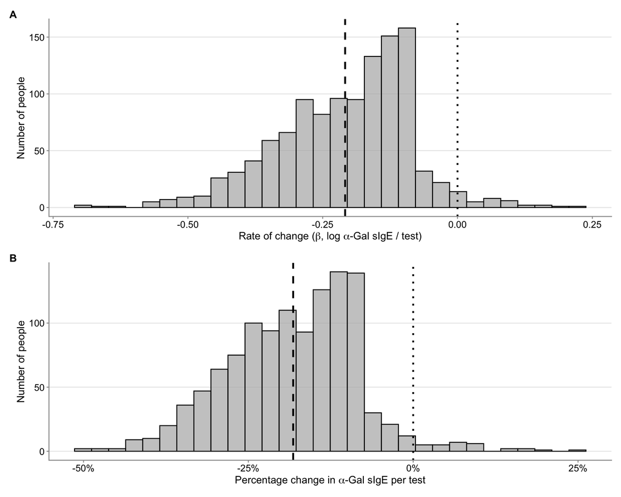

```r
library("patchwork")

slope_plots <- (individual_slopes_plt / individual_slopes_pct_plt) +
  plot_annotation(tag_levels = 'A') &
  theme(plot.tag = element_text(face = "bold", size = 12))

slope_plots
```

Categorical summary plot of change direction

```r
# Create a cleaner categorical visualization
individual_slopes_pct_sum <- individual_slopes_pct %>%
  count(change_direction) %>%
  mutate(
    percentage = round((n / sum(n)) * 100, 1),
    change_direction = fct_reorder(change_direction, n)
  ) %>%
  ggplot(aes(x = change_direction, y = percentage)) +
  geom_col(fill = "grey70", alpha = 0.7, color = "black") +
  geom_text(
    aes(label = paste0(percentage, "%\n(n=", n, ")")),
    vjust = -0.5,
    size = 3.5
  ) +
  labs(
    #title = "Distribution of Individual Patient Trends",
    #subtitle = "Percentage of patients in each change category",
    x = NULL,
    y = "Percentage of people (%)"
  ) +
  # theme(
  #   axis.text.x = element_text(angle = 45, hjust = 1)
  # ) +
  scale_y_continuous(limits = c(0, 100)) +
  scale_x_discrete(
    labels = function(x) gsub(" ", "\n", x)  # Replace spaces with line breaks
  )
```

### Time to 50% Reduction

Calculate and visualise the time (in years since first test) for each patient to achieve a 50% reduction in sIgE levels from their baseline.

```r
# Calculate time to 50% reduction for each patient (more clinically relevant)
time_to_half <- multi_test_df %>%
  #filter(Status == "Positive") %>%
  group_by(pat_ID) %>%
  arrange(YOT, .by_group = TRUE) %>%
  mutate(
    first_aGal = first(aGal),
    pct_of_first = (aGal / first_aGal) * 100,
    years_since_first = YOT - first(YOT),
    reached_50pct = pct_of_first <= 50
  ) %>%
  filter(reached_50pct) %>%
  slice(1) %>% # First time reaching 50%
  ungroup()

# Plot time to 50% reduction
time_to_half_plt <- time_to_half %>%
  ggplot(aes(x = years_since_first)) +
  geom_histogram(bins = 9, fill = "grey70", alpha = 0.7, color = "black") +
  geom_vline(
    xintercept = median(time_to_half$years_since_first),
    linetype = 2,
    color = "black",
    size = 1
  ) +
  labs(
    #title = "Time to 50% Reduction in aGal Levels",
    # subtitle = paste0(
    #   "Among ",
    #   nrow(time_to_half),
    #   " people who achieved 50% reduction"
    # ),
    x = "Years since first test",
    y = "Number of people"
  ) +
  theme(
    panel.grid.minor = element_blank(),
    panel.grid.major.x = element_blank()
  )
```

Combining all plots

Assemble individual slope histograms, percentage change distribution, categorical summary, and time-to-50% reduction into a four-panel composite figure.

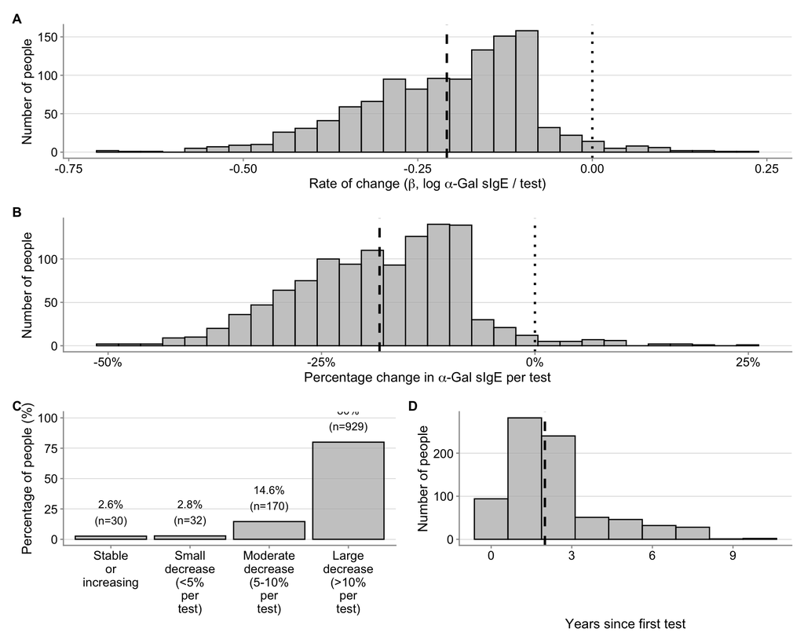

```r
combined_all <-
  (individual_slopes_plt / individual_slopes_pct_plt) /
  (individual_slopes_pct_sum + time_to_half_plt) +
  plot_annotation(tag_levels = 'A') &
  theme(plot.tag = element_text(face = "bold", size = 12))

combined_all
```

```r
ggsave(
  "plots/Final_plots/aGal_levels.png",
  combined_all,
  width = 20,
  height = 15,
  dpi = 300,
  bg = "white"
)
```

# Calendar Time Analysis

Re-analyse sIgE trajectories using actual calendar time (years since first test) rather than sequential test number, to account for variable inter-test intervals.

```r
library(tidyverse)
library(lme4)
library(lmerTest)
library(broom.mixed)
library(patchwork)
```

## Dataset Preparation

Prepare the dataset with actual elapsed time since each patient’s first test.

```r
# Prepare data with actual calendar time
positive_patients_lme_time <- multi_test_df %>%
  # Remove patients who never had a positive test
  group_by(pat_ID) %>%
  filter(any(Status == "Positive")) %>%
  ungroup() %>%
  ###
  group_by(pat_ID) %>%
  mutate(
    years_since_first = YOT - min(YOT),  # Actual years elapsed
    log_aGal = log(aGal +1)
  ) %>%
  ungroup()

# Filter to patients with at least 2 tests
patients_with_multiple <- positive_patients_lme_time %>%
  group_by(pat_ID) %>%
  filter(n() >= 2, max(years_since_first) > 0) %>%  # Must have time span > 0
  ungroup()

cat("=== DATASET SUMMARY ===\n")
cat("Total positive patients with ≥2 tests:", n_distinct(patients_with_multiple$pat_ID), "\n")
cat("Total observations:", nrow(patients_with_multiple), "\n")
cat("Median time span:",
    median((patients_with_multiple %>%
            group_by(pat_ID) %>%
            summarise(span = max(years_since_first)) %>%
            pull(span))), "years\n\n")
```

```
=== DATASET SUMMARY ===
Total positive patients with ≥2 tests: 1017
Total observations: 2952
Median time span: 2 years
```

## Mixed-Effects Model: Calendar Time

Fit a linear mixed-effects model with years since first test as the predictor, extracting both population-average and individual-level slopes.

```r
# Fit linear mixed effects model with time in years
time_lme_model <- lmer(
  log_aGal ~ years_since_first + (1 + years_since_first | pat_ID),
  data = patients_with_multiple,
  REML = TRUE
)

cat("=== MIXED EFFECTS MODEL (Calendar Time) ===\n")
print(summary(time_lme_model))

model_summary <- summary(time_lme_model)
coef(model_summary)

# Extract fixed effects
time_fixed <- fixef(time_lme_model)
time_fixed_intercept <- time_fixed[1]
time_fixed_slope <- time_fixed[2]

# Get confidence intervals
time_ci <- confint(time_lme_model, parm = "beta_", method = "Wald")

cat("\n=== FIXED EFFECTS (Population Average) ===\n")
cat("Intercept:", round(time_fixed_intercept, 4), "\n")
cat("Slope (log units/year):", round(time_fixed_slope, 4), "\n")
cat("95% CI:", round(time_ci[2,1], 4), "to", round(time_ci[2,2], 4), "\n")
cat("Annual % change:", round((exp(time_fixed_slope) - 1) * 100, 2), "%\n\n")

# Extract individual slopes (random effects)
time_ranef <- ranef(time_lme_model)$pat_ID
time_individual_slopes <- data.frame(
  pat_ID = rownames(time_ranef),
  individual_intercept = time_ranef[,1] + time_fixed_intercept,
  individual_slope = time_ranef[,2] + time_fixed_slope
)

# Add patient info
time_individual_slopes <- time_individual_slopes %>%
  left_join(
    patients_with_multiple %>%
      group_by(pat_ID) %>%
      summarise(
        Sex = first(Sex),
        n_tests = n(),
        time_span_years = max(years_since_first),
        .groups = "drop"
      ),
    by = "pat_ID"
  )
```

```
=== MIXED EFFECTS MODEL (Calendar Time) ===
Linear mixed model fit by REML. t-tests use Satterthwaite's method [
lmerModLmerTest]
Formula: log_aGal ~ years_since_first + (1 + years_since_first | pat_ID)
   Data: patients_with_multiple

REML criterion at convergence: 7736.3

Scaled residuals:
    Min      1Q  Median      3Q     Max
-2.9001 -0.4499 -0.1294  0.4076  3.8457

Random effects:
 Groups   Name              Variance Std.Dev. Corr
 pat_ID   (Intercept)       0.99037  0.9952
          years_since_first 0.03665  0.1915   -0.57
 Residual                   0.35178  0.5931
Number of obs: 2952, groups:  pat_ID, 1017

Fixed effects:
                    Estimate Std. Error         df t value Pr(>|t|)
(Intercept)          1.52359    0.03494 1006.32606   43.61   <2e-16 ***
years_since_first   -0.14156    0.01022  497.10906  -13.85   <2e-16 ***
---
Signif. codes:  0 '***' 0.001 '**' 0.01 '*' 0.05 '.' 0.1 ' ' 1

Correlation of Fixed Effects:
            (Intr)
yrs_snc_frs -0.525
                    Estimate Std. Error        df   t value      Pr(>|t|)
(Intercept)        1.5235929 0.03493810 1006.3261  43.60834 4.035488e-234
years_since_first -0.1415597 0.01022358  497.1091 -13.84639  4.153672e-37

=== FIXED EFFECTS (Population Average) ===
Intercept: 1.5236
Slope (log units/year): -0.1416
95% CI: -0.1616 to -0.1215
Annual % change: -13.2 %
```

```r
cat("=== INDIVIDUAL SLOPES SUMMARY ===\n")
cat("Mean individual slope:", round(mean(time_individual_slopes$individual_slope), 4),
    "log units/year\n")
cat("Median individual slope:", round(median(time_individual_slopes$individual_slope), 4),
    "log units/year\n")
cat("SD:", round(sd(time_individual_slopes$individual_slope), 4), "\n")
cat("Range:", round(min(time_individual_slopes$individual_slope), 4), "to",
    round(max(time_individual_slopes$individual_slope), 4), "\n")
cat("% with negative slopes:",
    round(sum(time_individual_slopes$individual_slope < 0) /
          nrow(time_individual_slopes) * 100, 1), "%\n\n")
summary(time_individual_slopes$individual_slope)

model_summary <- summary(time_lme_model)
coef(model_summary)
```

```
=== INDIVIDUAL SLOPES SUMMARY ===
Mean individual slope: -0.1416 log units/year
Median individual slope: -0.1239 log units/year
SD: 0.1211
Range: -0.5598 to 0.2726
% with negative slopes: 93.2 %

    Min.  1st Qu.   Median     Mean  3rd Qu.     Max.
-0.55977 -0.22055 -0.12390 -0.14156 -0.05927  0.27255
                    Estimate Std. Error        df   t value      Pr(>|t|)
(Intercept)        1.5235929 0.03493810 1006.3261  43.60834 4.035488e-234
years_since_first -0.1415597 0.01022358  497.1091 -13.84639  4.153672e-37
```

## Variance Decomposition

Quantify the proportion of variance in sIgE levels explained by time, individual patient differences, and residual variation using marginal and conditional R-squared values.

```r
# Calculate variance explained by time
library(MuMIn)

# Get R² values
r_squared <- r.squaredGLMM(time_lme_model)

cat("\n=== VARIANCE EXPLAINED BY TIME ===\n")
cat("R² marginal (time alone):", round(r_squared[1], 3),
    "=", round(r_squared[1] * 100, 1), "%\n")
cat("R² conditional (time + individual differences):", round(r_squared[2], 3),
    "=", round(r_squared[2] * 100, 1), "%\n\n")

# Also calculate from variance components
var_components <- as.data.frame(VarCorr(time_lme_model))

var_intercept <- var_components$vcov[1]  # Between-patient variance
var_slope <- var_components$vcov[2]      # Trajectory variance
var_residual <- var_components$vcov[3]   # Unexplained variance

total_var <- var_intercept + var_slope + var_residual

cat("=== VARIANCE DECOMPOSITION ===\n")
cat("Between-patient baseline:", round(var_intercept/total_var * 100, 1), "%\n")
cat("Individual trajectories (time-related):", round(var_slope/total_var * 100, 1), "%\n")
cat("Residual (unexplained):", round(var_residual/total_var * 100, 1), "%\n")
```

```
=== VARIANCE EXPLAINED BY TIME ===
R² marginal (time alone): 0.067 = 6.7 %
R² conditional (time + individual differences): 0.734 = 73.4 %

=== VARIANCE DECOMPOSITION ===
Between-patient baseline: 107.8 %
Individual trajectories (time-related): 4 %
Residual (unexplained): -11.8 %
```

```r
# The R² for fixed effects only (time)
# Calculate marginal R² - variance explained by time alone
library(MuMIn)
r_squared <- r.squaredGLMM(time_lme_model)

cat("=== VARIANCE EXPLAINED ===\n")
cat("R² marginal (fixed effects/time only):", round(r_squared[1], 3), "\n")
cat("R² conditional (fixed + random effects):", round(r_squared[2], 3), "\n")
cat("\nInterpretation:\n")
cat("- Time alone explains", round(r_squared[1] * 100, 1), "% of variance\n")
cat("- Time + individual differences explain", round(r_squared[2] * 100, 1), "% of variance\n")
```

```
=== VARIANCE EXPLAINED ===
R² marginal (fixed effects/time only): 0.067
R² conditional (fixed + random effects): 0.734

Interpretation:
- Time alone explains 6.7 % of variance
- Time + individual differences explain 73.4 % of variance
```

## Factors Predicting Rate of Decline

Investigate whether baseline sIgE concentration predicts the rate of subsequent decline, using correlation analysis of individual random effects.

```r
# Extract individual random effects
individual_effects <- data.frame(
  pat_ID = rownames(ranef(time_lme_model)$pat_ID),
  baseline_deviation = ranef(time_lme_model)$pat_ID[,1],  # Random intercept
  slope_deviation = ranef(time_lme_model)$pat_ID[,2]      # Random slope
)

# Add actual baseline sIgE level
individual_effects <- individual_effects %>%
  left_join(
    patients_with_multiple %>%
      group_by(pat_ID) %>%
      filter(years_since_first == 0) %>%
      select(pat_ID, baseline_aGal = aGal, baseline_log_aGal = log_aGal) %>%
      distinct(),
    by = "pat_ID"
  )

# Calculate actual individual slopes (fixed + random)
individual_effects <- individual_effects %>%
  mutate(
    actual_slope = time_fixed_slope + slope_deviation,
    actual_intercept = time_fixed_intercept + baseline_deviation
  )

cat("=== FACTORS PREDICTING RATE OF DECLINE ===\n\n")

# 1. Correlation between baseline level and slope
cor_test <- cor.test(individual_effects$baseline_log_aGal,
                     individual_effects$actual_slope,
                     method = "pearson")

cat("1. BASELINE LEVEL vs RATE OF DECLINE:\n")
cat("   Correlation:", round(cor_test$estimate, 3), "\n")
cat("   95% CI:", round(cor_test$conf.int[1], 3), "to",
    round(cor_test$conf.int[2], 3), "\n")
cat("   p-value:", format.pval(cor_test$p.value), "\n")
cat("   Interpretation: Higher baseline → ",
    ifelse(cor_test$estimate < 0, "FASTER", "SLOWER"), " decline\n\n")

# 2. Linear regression: Does baseline predict slope?
baseline_model <- lm(actual_slope ~ baseline_log_aGal, data = individual_effects)
baseline_summary <- summary(baseline_model)

cat("2. LINEAR REGRESSION MODEL:\n")
cat("   Model: Slope = β₀ + β₁ × log(baseline sIgE)\n")
cat("   β₁ (effect of baseline):", round(coef(baseline_summary)[2,1], 4), "\n")
cat("   SE:", round(coef(baseline_summary)[2,2], 4), "\n")
cat("   p-value:", format.pval(coef(baseline_summary)[2,4]), "\n")
cat("   R²:", round(baseline_summary$r.squared, 3),
    "=", round(baseline_summary$r.squared * 100, 1), "% of variance in decline rate\n\n")

cat("   Interpretation: For each 1-unit increase in log(baseline sIgE),\n")
cat("   the annual decline rate changes by",
    round(coef(baseline_summary)[2,1], 4), "log units/year\n\n")
```

```
=== FACTORS PREDICTING RATE OF DECLINE ===

1. BASELINE LEVEL vs RATE OF DECLINE:
   Correlation: -0.78
   95% CI: -0.802 to -0.756
   p-value: < 2.22e-16
   Interpretation: Higher baseline →  FASTER  decline

2. LINEAR REGRESSION MODEL:
   Model: Slope = β₀ + β₁ × log(baseline sIgE)
   β₁ (effect of baseline): -0.0803
   SE: 0.0019
   p-value: < 2.22e-16
   R²: 0.609 = 60.9 % of variance in decline rate

   Interpretation: For each 1-unit increase in log(baseline sIgE),
   the annual decline rate changes by -0.0803 log units/year
```

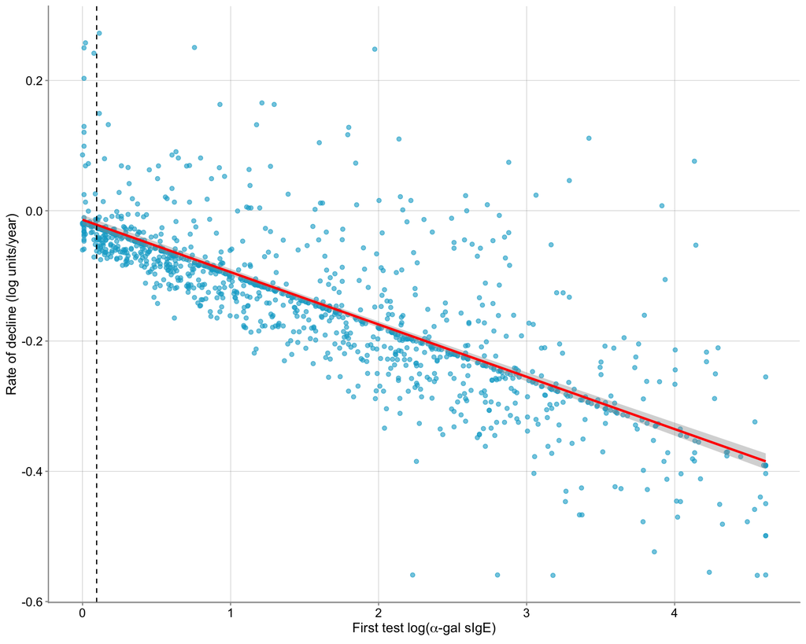

```r
# 3. Visualize the relationship
baseline_slope_plot <- ggplot(individual_effects,
                               aes(x = baseline_log_aGal, y = actual_slope)) +
  geom_point(alpha = 0.6, color = MiddayBlue) +
  geom_smooth(method = "lm", se = TRUE, color = "red") +
  geom_vline(xintercept = log(0.1 + 1), linetype = "dashed", color = "black") +
  labs(
    # title = "Baseline sIgE Level Predicts Rate of Decline",
    # subtitle = paste0("r = ", round(cor_test$estimate, 3),
    #                  ", p ", ifelse(cor_test$p.value < 0.001, "< 0.001",
    #                                paste0("= ", round(cor_test$p.value, 3)))),
    x = expression("First test log("  * alpha * "-gal sIgE)"),
    y = "Rate of decline (log units/year)"
  ) +
  theme(panel.grid.major.x = element_line(colour = "grey60", linewidth = 0.1))

print(baseline_slope_plot)
```

```r
# 4. Summary by baseline quartiles
individual_effects <- individual_effects %>%
  mutate(baseline_quartile = ntile(baseline_log_aGal, 4))

quartile_summary <- individual_effects %>%
  group_by(baseline_quartile) %>%
  summarise(
    n = n(),
    median_baseline = median(exp(baseline_log_aGal) - 1),  # Back to original scale
    median_slope = median(actual_slope),
    mean_slope = mean(actual_slope),
    pct_negative_slope = mean(actual_slope < 0) * 100
  )

cat("3. DECLINE RATE BY BASELINE QUARTILE:\n")
print(quartile_summary, n = 4)
```

```
3. DECLINE RATE BY BASELINE QUARTILE:
# A tibble: 4 × 6
  baseline_quartile     n median_baseline median_slope mean_slope
              <int> <int>           <dbl>        <dbl>      <dbl>
1                 1   281            0.27      -0.0439    -0.0344
2                 2   281            1.53      -0.102     -0.0919
3                 3   281            6.39      -0.186     -0.173
4                 4   281           22         -0.279     -0.274
# ℹ 1 more variable: pct_negative_slope <dbl>
```

## MODEL DIAGNOSTICS AND ASSUMPTION CHECKING

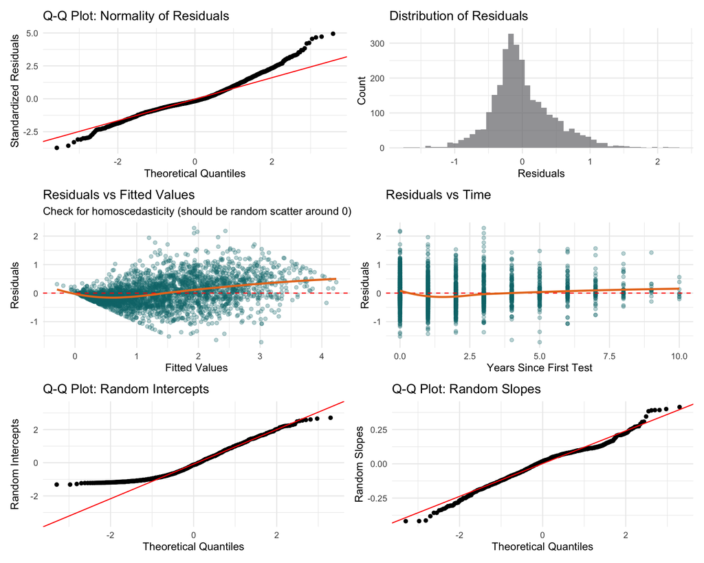

```r
# Extract residuals and fitted values
model_diagnostics <- patients_with_multiple %>%
  mutate(
    fitted = fitted(time_lme_model),
    residuals = residuals(time_lme_model),
    standardized_resid = residuals / sd(residuals)
  )

# 1. Normality of residuals (QQ plot)
qq_plot <- ggplot(model_diagnostics, aes(sample = standardized_resid)) +
  stat_qq() +
  stat_qq_line(color = "red") +
  labs(title = "Q-Q Plot: Normality of Residuals",
       x = "Theoretical Quantiles",
       y = "Standardized Residuals") +
  theme_minimal()

# 2. Histogram of residuals
resid_hist <- ggplot(model_diagnostics, aes(x = residuals)) +
  geom_histogram(bins = 50, fill = Steel, alpha = 0.7) +
  labs(title = "Distribution of Residuals",
       x = "Residuals",
       y = "Count") +
  theme_minimal()

# 3. Residuals vs Fitted (check homoscedasticity)
resid_fitted <- ggplot(model_diagnostics, aes(x = fitted, y = residuals)) +
  geom_point(alpha = 0.3, color = Teal) +
  geom_hline(yintercept = 0, color = "red", linetype = "dashed") +
  geom_smooth(method = "loess", se = FALSE, color = Orange) +
  labs(title = "Residuals vs Fitted Values",
       subtitle = "Check for homoscedasticity (should be random scatter around 0)",
       x = "Fitted Values",
       y = "Residuals") +
  theme_minimal()

# 4. Residuals vs Time (check for temporal patterns)
resid_time <- ggplot(model_diagnostics, aes(x = years_since_first, y = residuals)) +
  geom_point(alpha = 0.3, color = Teal) +
  geom_hline(yintercept = 0, color = "red", linetype = "dashed") +
  geom_smooth(method = "loess", se = FALSE, color = Orange) +
  labs(title = "Residuals vs Time",
       x = "Years Since First Test",
       y = "Residuals") +
  theme_minimal()

# 5. Check normality of random effects
random_effects_df <- data.frame(
  intercept = ranef(time_lme_model)$pat_ID[,1],
  slope = ranef(time_lme_model)$pat_ID[,2]
)

qq_random_int <- ggplot(random_effects_df, aes(sample = intercept)) +
  stat_qq() +
  stat_qq_line(color = "red") +
  labs(title = "Q-Q Plot: Random Intercepts",
       x = "Theoretical Quantiles",
       y = "Random Intercepts") +
  theme_minimal()

qq_random_slope <- ggplot(random_effects_df, aes(sample = slope)) +
  stat_qq() +
  stat_qq_line(color = "red") +
  labs(title = "Q-Q Plot: Random Slopes",
       x = "Theoretical Quantiles",
       y = "Random Slopes") +
  theme_minimal()

# Combine all diagnostic plots
library(patchwork)
diagnostics_combined <- (qq_plot | resid_hist) /
                        (resid_fitted | resid_time) /
                        (qq_random_int | qq_random_slope)

print(diagnostics_combined)
```

```r
# Formal statistical tests
cat("\n=== FORMAL ASSUMPTION TESTS ===\n")

# Shapiro-Wilk test for normality of residuals (on sample if n > 5000)
if(nrow(model_diagnostics) > 5000) {
  shapiro_resid <- shapiro.test(sample(model_diagnostics$residuals, 5000))
} else {
  shapiro_resid <- shapiro.test(model_diagnostics$residuals)
}
cat("Shapiro-Wilk test (residuals): W =", round(shapiro_resid$statistic, 4),
    ", p =", format.pval(shapiro_resid$p.value), "\n")

# Shapiro-Wilk for random effects
shapiro_int <- shapiro.test(random_effects_df$intercept)
shapiro_slope <- shapiro.test(random_effects_df$slope)
cat("Shapiro-Wilk test (random intercepts): W =", round(shapiro_int$statistic, 4),
    ", p =", format.pval(shapiro_int$p.value), "\n")
cat("Shapiro-Wilk test (random slopes): W =", round(shapiro_slope$statistic, 4),
    ", p =", format.pval(shapiro_slope$p.value), "\n")

# Breusch-Pagan test for heteroscedasticity (requires lmtest package)
# install.packages("lmtest") if needed
library(lmtest)
bp_test <- bptest(residuals ~ fitted, data = model_diagnostics)
cat("\nBreusch-Pagan test (homoscedasticity): BP =", round(bp_test$statistic, 2),
    ", p =", format.pval(bp_test$p.value), "\n")
```

```
=== FORMAL ASSUMPTION TESTS ===
Shapiro-Wilk test (residuals): W = 0.9659 , p = < 2.22e-16
Shapiro-Wilk test (random intercepts): W = 0.9436 , p = < 2.22e-16
Shapiro-Wilk test (random slopes): W = 0.9806 , p = 2.1994e-10

Breusch-Pagan test (homoscedasticity): BP = 209.44 , p = < 2.22e-16
```

## PERCENTAGE CHANGE ANALYSIS

```r
# Convert slopes to annual percentage change
individual_slopes_pct_time <- time_individual_slopes %>%
  mutate(
    annual_pct_change = (exp(individual_slope) - 1) * 100,
    change_direction = case_when(
      annual_pct_change < -10 ~ "Large decrease",
      annual_pct_change < -5 ~ "Moderate decrease",
      annual_pct_change < -2 ~ "Small decrease",
      annual_pct_change <= 2 ~ "Essentially stable",
      annual_pct_change <= 5 ~ "Small increase",
      annual_pct_change <= 10 ~ "Moderate increase",
      TRUE ~ "Large increase"
    ),
    change_direction = factor(
      change_direction,
      levels = c("Large decrease", "Moderate decrease", "Small decrease",
                 "Essentially stable", "Small increase", "Moderate increase",
                 "Large increase")
    )
  )

cat("=== ANNUAL PERCENTAGE CHANGE DISTRIBUTION ===\n")
print(table(individual_slopes_pct_time$change_direction))
cat("\n")
```

```
=== ANNUAL PERCENTAGE CHANGE DISTRIBUTION ===

    Large decrease  Moderate decrease     Small decrease Essentially stable
               577                219                121                 47
    Small increase  Moderate increase     Large increase
                12                 21                 20
```

# FIRST VS LAST COMPARISON

```r
first_last_comparison_time <- patients_with_multiple %>%
  # Remove patients who never had a positive test
  group_by(pat_ID) %>%
  filter(any(Status == "Positive")) %>%
  ungroup() %>%
  ###
  group_by(pat_ID) %>%
  arrange(years_since_first, .by_group = TRUE) %>%
  summarise(
    first_aGal = first(aGal),
    last_aGal = last(aGal),
    first_log_aGal = log(first_aGal +1),
    last_log_aGal = log(last_aGal + 1),
    time_span_years = max(years_since_first),
    n_tests = n(),
    Sex = first(Sex),
    decreased = last_aGal < first_aGal,
    .groups = "drop"
  ) %>%
  filter(time_span_years > 0)

# Paired t-test
paired_ttest_time <- t.test(
  first_last_comparison_time$last_log_aGal,
  first_last_comparison_time$first_log_aGal,
  paired = TRUE
)

cat("=== FIRST VS LAST TEST COMPARISON ===\n")
cat("N patients:", nrow(first_last_comparison_time), "\n")
cat("Median time span:", median(first_last_comparison_time$time_span_years), "years\n")
cat("% with decreased levels:",
    round(sum(first_last_comparison_time$decreased) /
          nrow(first_last_comparison_time) * 100, 1), "%\n")
cat("\nPaired t-test (log scale):\n")
cat("  Mean difference:", round(paired_ttest_time$estimate, 4), "\n")
cat("  t =", round(paired_ttest_time$statistic, 3), "\n")
cat("  p-value:", format.pval(paired_ttest_time$p.value, digits = 3), "\n")
cat("  95% CI:", round(paired_ttest_time$conf.int[1], 4), "to",
    round(paired_ttest_time$conf.int[2], 4), "\n\n")
```

```
=== FIRST VS LAST TEST COMPARISON ===
N patients: 1017
Median time span: 2 years
% with decreased levels: 73.7 %

Paired t-test (log scale):
  Mean difference: -0.5218
  t = -15.454
  p-value: <2e-16
  95% CI: -0.588 to -0.4555
```

# PLOTS - CALENDAR TIME

```r
# Plot 1: Distribution of individual slopes (log units/year)
individual_slopes_plt_time <- individual_slopes_pct_time %>%
  ggplot(aes(x = individual_slope)) +
  geom_histogram(bins = 30, fill = "grey70", alpha = 0.7, color = "black") +
  geom_vline(xintercept = 0, linetype = "dotted", color = "black", linewidth = 1) +
  geom_vline(
    xintercept = median(individual_slopes_pct_time$individual_slope),
    linetype = "dashed",
    color = "black",
    linewidth = 1
  ) +
  labs(
    x = expression("Annual rate of change (" * beta * ", log " * alpha * "-Gal sIgE / year)"),
    y = "Number of people"
  )
```

```r
# Plot 2: Distribution of annual percentage change
individual_slopes_pct_plt_time <- individual_slopes_pct_time %>%
  ggplot(aes(x = annual_pct_change)) +
  geom_histogram(bins = 30, fill = "grey70", alpha = 0.7, color = "black") +
  geom_vline(xintercept = 0, linetype = "dotted", color = "black", linewidth = 1) +
  geom_vline(
    xintercept = median(individual_slopes_pct_time$annual_pct_change),
    linetype = "dashed",
    color = "black",
    linewidth = 1
  ) +
  scale_x_continuous(
    labels = function(x) paste0(x, "%")
  ) +
  labs(
    x = expression("Annual percentage change in " * alpha * "-Gal sIgE"),
    y = "Number of people"
  )
```

```r
# Scatter plot: first vs last aGal levels
first_last_comparison_plt <- first_last_comparison_time %>%
  ggplot(aes(x = first_log_aGal, y = last_log_aGal)) +
  geom_point(aes(color = decreased), alpha = 0.7, size = 2) +
  geom_abline(slope = 1, intercept = 0, linetype = "dashed", color = "grey20", lwd = 0.5) +
  geom_smooth(method = "lm", se = TRUE, color = "red", alpha = 0.3) +
  scale_color_manual(
    values = c("FALSE" = MidnightBlue, "TRUE" = MiddayBlue),
    labels = c("FALSE" = "Increased", "TRUE" = "Decreased"),
    name = "Change"
  ) +
  labs(
    #title = "First vs Last aGal Test Levels",
    #subtitle = "Points below diagonal line indicate decrease",
    x = expression("First test (log " * alpha * "-Gal sIgE)"),
    y = expression("Last test (log " * alpha * "-Gal sIgE)")
  ) +
  theme(
    panel.grid.major.x = element_line(colour = "grey60", linewidth = 0.1),
    legend.position = "bottom"
  ) +
  theme(
    legend.position = c(0.99, 0.99),
    legend.justification = c("right", "top"),
    legend.text = element_text(size = 11),
    legend.title = element_blank(),
    legend.key.size = unit(0.5, "cm"),
    legend.box.background = element_rect(
      fill = "white",
      colour = "grey50",
      linewidth = 0.7
    )
  ) +
  guides(color = guide_legend(override.aes = list(size = 3, alpha = 1))) +
  # Annotation lines for reference at log(0.1 +1)
  geom_hline(yintercept = log(0.1 +1), linetype = "dotted", color = "grey20", lwd = 0.5) +
  geom_vline(xintercept = log(0.1 +1), linetype = "dotted", color = "grey20", lwd = 0.5) +
  theme(
    panel.grid.major.y = element_line(colour = "grey80", linewidth = 0.1)
  )
```

```r
# First test vs rate of decline
baseline_slope_plot <- ggplot(individual_effects,
                               aes(x = baseline_log_aGal, y = actual_slope)) +
  geom_hline(yintercept = 0, linetype = "dashed", color = "grey40", linewidth = 0.8) +
  geom_point(aes(color = actual_slope < 0), alpha = 0.6, size = 2) +
  geom_smooth(method = "lm", se = TRUE, color = "red", alpha = 0.3) +
  geom_vline(xintercept = log(0.1 + 1), linetype = "dotted", color = "black") +
  scale_color_manual(
    values = c("FALSE" = MidnightBlue, "TRUE" = MiddayBlue),
    labels = c("FALSE" = "Increasing", "TRUE" = "Decreasing"),
    name = "Trajectory"
  ) +
  labs(
    x = expression("First test log("  * alpha * "-gal sIgE)"),
    y = "Rate of decline (log units/year)"
  ) +
  theme(
    panel.grid.major.x = element_line(colour = "grey60", linewidth = 0.1),
    legend.position = c(0.99, 0.99),
    legend.justification = c("right", "top"),
    legend.text = element_text(size = 11),
    legend.title = element_blank(),
    legend.key.size = unit(0.5, "cm"),
    legend.box.background = element_rect(
      fill = "white",
      colour = "grey50",
      linewidth = 0.7
    )
  ) +
  guides(color = guide_legend(override.aes = list(size = 3, alpha = 1)))
```

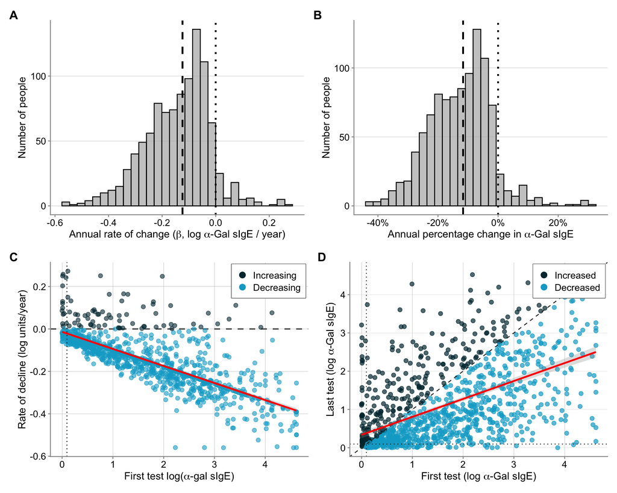

```r
# Combine plots
final_combined_time <-
  (individual_slopes_plt_time + individual_slopes_pct_plt_time) /
  (baseline_slope_plot + first_last_comparison_plt) +
  plot_annotation(tag_levels = 'A') &
  theme(plot.tag = element_text(face = "bold", size = 14))

print(final_combined_time)
```

```r
# Save
ggsave(
  "plots/Final_plots/Fig_6_aGal_levles.png",
  final_combined_time,
  width = 30,
  height = 30,
  units = "cm",
  dpi = 300,
  bg = "white"
)
```

```r
median(individual_slopes_pct_time$annual_pct_change)
```

```
[1] -11.65346
```

# How many went from positive to negative

```r
seroconversion_analysis <- first_last_comparison_time %>%
  mutate(
    first_positive = first_aGal > 0.1,
    last_negative = last_aGal <= 0.1,
    seroconverted = first_positive & last_negative
  ) %>%
  summarise(
    n_first_positive = sum(first_positive),
    n_seroconverted = sum(seroconverted),
    prop_seroconverted = mean(seroconverted),
    pct_seroconverted = mean(seroconverted) * 100
  )

cat("=== SEROCONVERSION ANALYSIS ===\n")
cat("Patients positive at first test:", seroconversion_analysis$n_first_positive, "\n")
cat("Patients who became negative (<0.1):", seroconversion_analysis$n_seroconverted, "\n")
cat("Proportion:", round(seroconversion_analysis$prop_seroconverted, 3),
    "(", round(seroconversion_analysis$pct_seroconverted, 1), "%)\n\n")
```

```
=== SEROCONVERSION ANALYSIS ===
Patients positive at first test: 964
Patients who became negative (<0.1): 110
Proportion: 0.108 ( 10.8 %)
```

# Paired t-test: First vs last

```r
# Prepare first vs last test comparison
first_last_comparison <- multi_test_df %>%
  #filter(Status == "Positive") %>%
  group_by(pat_ID) %>%
  arrange(YOT, .by_group = TRUE) %>%
  summarise(
    n_tests = n(),
    first_aGal = first(aGal),
    last_aGal = last(aGal),
    first_log_aGal = log(first_aGal + 1),
    last_log_aGal = log(last_aGal + 1),
    time_span = last(YOT) - first(YOT),
    .groups = "drop"
  ) %>%
  filter(n_tests >= 2, time_span > 0) %>% # Only patients with multiple tests over time
  mutate(
    raw_change = last_aGal - first_aGal,
    log_change = last_log_aGal - first_log_aGal,
    pct_change = ((last_aGal - first_aGal) / first_aGal) * 100,
    decreased = last_aGal < first_aGal
  )

# Paired t-test on log-transformed values
paired_ttest_log <- t.test(
  first_last_comparison$first_log_aGal,
  first_last_comparison$last_log_aGal,
  paired = TRUE
)

# Paired t-test on raw values
paired_ttest_raw <- t.test(
  first_last_comparison$first_aGal,
  first_last_comparison$last_aGal,
  paired = TRUE
)

print("Paired t-test results (log-transformed):")
print(paired_ttest_log)

print("\nPaired t-test results (raw values):")
print(paired_ttest_raw)

# Summary statistics
first_last_summary <- first_last_comparison %>%
  summarise(
    n_patients = n(),
    n_decreased = sum(decreased),
    prop_decreased = mean(decreased),
    mean_pct_change = mean(pct_change),
    median_pct_change = median(pct_change),
    mean_time_span = mean(time_span),
    median_time_span = median(time_span)
  )

print("\nFirst vs Last Test Summary:")
print(first_last_summary)
```

```
[1] "Paired t-test results (log-transformed):"

    Paired t-test

data:  first_last_comparison$first_log_aGal and first_last_comparison$last_log_aGal
t = 15.195, df = 1220, p-value < 2.2e-16
alternative hypothesis: true mean difference is not equal to 0
95 percent confidence interval:
 0.3792114 0.4916574
sample estimates:
mean difference
      0.4354344

[1] "\nPaired t-test results (raw values):"

    Paired t-test

data:  first_last_comparison$first_aGal and first_last_comparison$last_aGal
t = 9.636, df = 1220, p-value < 2.2e-16
alternative hypothesis: true mean difference is not equal to 0
95 percent confidence interval:
 3.370606 5.094014
sample estimates:
mean difference
        4.23231

[1] "\nFirst vs Last Test Summary:"
# A tibble: 1 × 7
  n_patients n_decreased prop_decreased mean_pct_change median_pct_change
       <int>       <int>          <dbl>           <dbl>             <dbl>
1       1221         828          0.678             NaN                NA
# ℹ 2 more variables: mean_time_span <dbl>, median_time_span <int>
```

# Wilcoxon signed-rank test (paired, non-parametric)

```r
# Wilcoxon signed-rank test for first vs last
wilcox_test <- wilcox.test(
  first_last_comparison$first_log_aGal,
  first_last_comparison$last_log_aGal,
  paired = TRUE
)

print("Wilcoxon signed-rank test (non-parametric):")
print(wilcox_test)

# Effect size for Wilcoxon test (r = Z / sqrt(N))
z_score <- qnorm(wilcox_test$p.value / 2) # Approximate Z-score
effect_size_r <- abs(z_score) / sqrt(nrow(first_last_comparison))

cat(sprintf("\nEffect size (r): %.3f\n", effect_size_r))
cat("Effect size interpretation: small (0.1), medium (0.3), large (0.5)\n")
```

```
[1] "Wilcoxon signed-rank test (non-parametric):"

    Wilcoxon signed rank test with continuity correction

data:  first_last_comparison$first_log_aGal and first_last_comparison$last_log_aGal
V = 481448, p-value < 2.2e-16
alternative hypothesis: true location shift is not equal to 0


Effect size (r): 0.449
Effect size interpretation: small (0.1), medium (0.3), large (0.5)
```

# Time to significant decrease analysis

```r
# Define significant decrease as >30% reduction from first test
significant_decrease_analysis <- multi_test_df %>%
  # Remove patients who never had a positive test
  group_by(pat_ID) %>%
  filter(any(Status == "Positive")) %>%
  ungroup() %>%
  ###
  group_by(pat_ID) %>%
  arrange(YOT, .by_group = TRUE) %>%
  mutate(
    first_aGal = first(aGal),
    pct_change_from_first = ((aGal - first_aGal) / first_aGal) * 100,
    years_since_first = YOT - first(YOT),
    significant_decrease = pct_change_from_first <= -50 # 30% or more decrease
  ) %>%
  # Find first time each patient achieved significant decrease
  filter(significant_decrease) %>%
  slice(1) %>% # First occurrence only
  ungroup() %>%
  dplyr::select(pat_ID, years_since_first, pct_change_from_first, first_aGal, aGal)

# Summary of time to significant decrease
if (nrow(significant_decrease_analysis) > 0) {
  time_to_decrease_summary <- significant_decrease_analysis %>%
    summarise(
      n_with_sig_decrease = n(),
      mean_time_to_decrease = mean(years_since_first),
      median_time_to_decrease = median(years_since_first),
      min_time = min(years_since_first),
      max_time = max(years_since_first),
      mean_pct_decrease = mean(pct_change_from_first)
    )

  print("Time to Significant Decrease (≥30%) Summary:")
  print(time_to_decrease_summary)

  # Calculate proportion of all positive patients who achieved significant decrease
  total_positive_patients <- length(unique(multi_test_df$pat_ID[
    multi_test_df$Status == "Positive"
  ]))
  prop_with_sig_decrease <- nrow(significant_decrease_analysis) /
    total_positive_patients

  cat(sprintf(
    "\nProportion achieving ≥50%% decrease: %.2f%% (%d of %d patients)\n",
    prop_with_sig_decrease * 100,
    nrow(significant_decrease_analysis),
    total_positive_patients
  ))
} else {
  cat("No patients achieved a ≥50% decrease in aGal levels.\n")
}
```

[output not shown]

# Summary of all stats tests

```r
# Compile all test results
statistical_summary <- data.frame(
  Test = c(
    "Linear Mixed-Effects (test number)",
    "Linear Mixed-Effects (years)",
    "Paired t-test (log values)",
    "Paired t-test (raw values)",
    "Wilcoxon signed-rank test",
    "Binomial test (prop. decreasing)"
  ),
  P_value = c(
    ifelse(exists("slope_pvalue"), slope_pvalue, NA),
    ifelse(exists("time_pvalue"), time_pvalue, NA),
    paired_ttest_log$p.value,
    paired_ttest_raw$p.value,
    wilcox_test$p.value,
    prop_test$p.value
  ),
  Significant = c(
    ifelse(exists("slope_pvalue"), slope_pvalue < 0.05, NA),
    ifelse(exists("time_pvalue"), time_pvalue < 0.05, NA),
    paired_ttest_log$p.value < 0.05,
    paired_ttest_raw$p.value < 0.05,
    wilcox_test$p.value < 0.05,
    prop_test$p.value < 0.05
  )
) %>%
  mutate(
    P_value = round(P_value, 6),
    Stars = case_when(
      P_value < 0.001 ~ "***",
      P_value < 0.01 ~ "**",
      P_value < 0.05 ~ "*",
      P_value < 0.1 ~ ".",
      TRUE ~ ""
    )
  )

print("SUMMARY OF ALL STATISTICAL TESTS:")
print("=================================")
print(statistical_summary)

cat("\nSignificance codes: 0 '***' 0.001 '**' 0.01 '*' 0.05 '.' 0.1 ' ' 1\n")
```

```
[1] "SUMMARY OF ALL STATISTICAL TESTS:"
[1] "================================="
                                Test P_value Significant Stars
1 Linear Mixed-Effects (test number)      NA          NA
2       Linear Mixed-Effects (years)      NA          NA
3         Paired t-test (log values)       0        TRUE   ***
4         Paired t-test (raw values)       0        TRUE   ***
5          Wilcoxon signed-rank test       0        TRUE   ***
6   Binomial test (prop. decreasing)       0        TRUE   ***

Significance codes: 0 '***' 0.001 '**' 0.01 '*' 0.05 '.' 0.1 ' ' 1
```